# Analisis sobre producción electrica en Sudamerica

Paulo Zepeda

10/4/2020

## 0.1 Introducción

- Buen modelo para comparar distintos escenarios de producción
- Países con distintos tamaños poblacionales y de economías diversas

**Objetivo de investigación**

- Determinar los países sudamericanos lideres en producción de electricidad según forma de generación entre los años 1991 y 2014
- Determinar los paises sudamericanso lideres en producción de electricidad per capita entre los años 1991 y 2014
- Generar un modelo lineal para proyectar la producción de energía años 2015-2019 usando como variables la cantidad producida y el PIB de cada país

## 0.2 Metodología

**Filtrar base de datos de la UNDS**

La base de datos generada por la UNDS, “El Cuestionario”, cuenta con mas de 1 millón de daos que recopilan información sobre el uso, almacenamiento, importación, generación de energía entre otras transacciónes. Esto para todos los paises del mundo entre los años 1990 y 2014. Dado el gran volumen de información es necesario focalizar el analisis en ciertos paises y transacciones. El objetivo de este trabajo esta centrado en paises sudamericanos, por ello el primer filtro aplicado es según paises dejando solo los siguientes:

Argentina, Bolivia, Brasil, Chile, Colombia, Ecuador, Guyana, Paraguay, Perú, Suriname, Trinidad y Tobago, Uruguay y Venezuela.

Luego el siguiente filtro esta en el tipo de energia, en este caso electrica, para evaluar solo transacciones de este tipo de energia se selecciono según “unidad”, en “El cuestionario” hay datos con distintas unidades como Toneladas metricas, Terajoules o Kilowatt-hour, esta ultima unidad de medida esta relacionada mas con generación electrica por lo que se uso como filtro para este encontrar este tipo de transaciones.

Para poder comparar las distintas industrias de los paises sudamericanos, se agrego el tamaño poblacional de cada pais entre 1991 y 2019, esto con la finalidad de tener una visión per capita de los niveles de producción de electricidad. La base de datos de la población por años fue obtenida de la pagina del Banco Mundial (CITA). En esta misma linea se agrego el PIB y PIB per capita, para comparar teniendo en cuenta el tamaño de las distintas economias. Los datos de PIB fueron obtenidos de la CEPAL (CITA) y el dato per capita del Banco Mundial (CITA)

**Análisis exploratorio**

## 0.3 Resultados

**Procesamiento bases de datos**

La base de datos de la UNDS cuenta con más de un millón de datos para los distintos países a escala mundial, es por ello que se realizó un filtro, enfocando así la investigación en países sudamericanos (13) específicamente en temas relacionados a Electricidad, dejando así un total de 8595 datos. Los resultados del filtro de los datos se exponen en la Figura 1

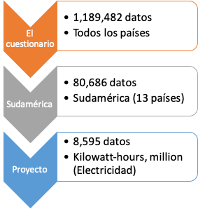

Figure 1: Esquema filtro de datos

**Producción Total**

El primer análisis exploratorio consistio en promediar la producción total de energia entre 1990 y 2014 para cada pais, los datos se exponen en la tabla 1

Table 1: Producción Total como actividad principal por paises

| country | Mean | SD |
| --- | --- | --- |
| Brazil | 340610.08 | 87082.13 |
| Venezuela (Bolivar. Rep.) | 92073.74 | 22767.98 |
| Argentina | 85475.41 | 24729.43 |
| Colombia | 48057.94 | 10516.91 |
| Paraguay | 47874.54 | 10137.91 |
| Chile | 41145.76 | 17010.22 |
| Peru | 22600.40 | 9985.87 |
| Ecuador | 11976.57 | 4015.81 |
| Uruguay | 8233.52 | 1540.88 |
| Trinidad and Tobago | 6187.88 | 1979.73 |
| Bolivia (Plur. State of) | 4607.72 | 1869.37 |
| Guyana | 451.39 | 179.33 |
| Suriname | 230.66 | 156.24 |

Esto se expone en la Figura 2 que contiene la producción total de electricidad por paises

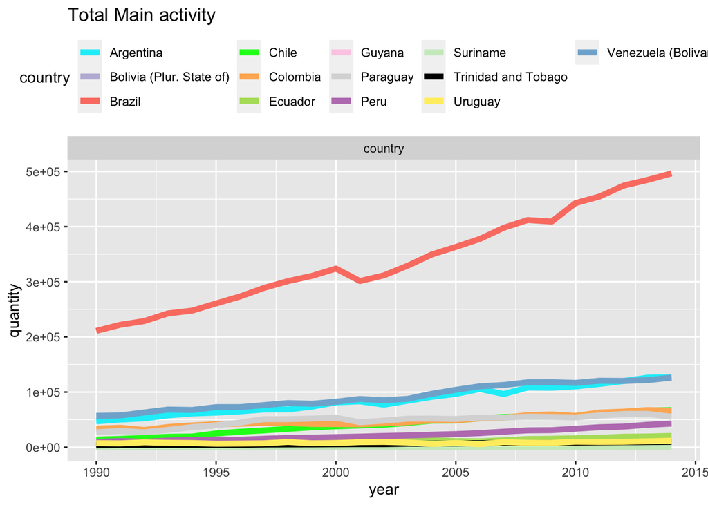

Figure 2: Producción total de electricidad

Sudamerica es un continente que alberga paises con distintas realidades, es asi como brasil se empina entre los mas poblados del mundo pero en el otro extremo hay paises con escasa población. Es por esto que se estandarizo la producción total por la cantidad de individuos como se detalla en la metodología.

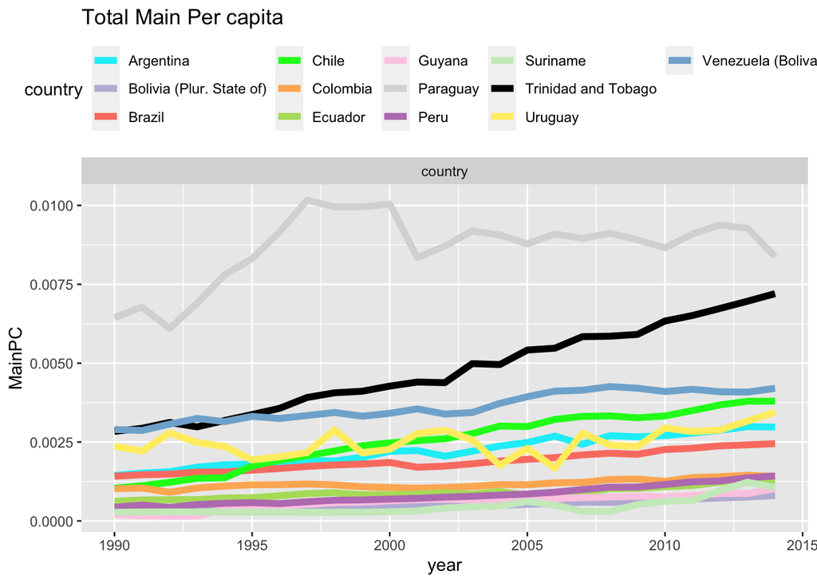

Figure 3: Producción total de electricidad per capita

**Produccion por combustión**

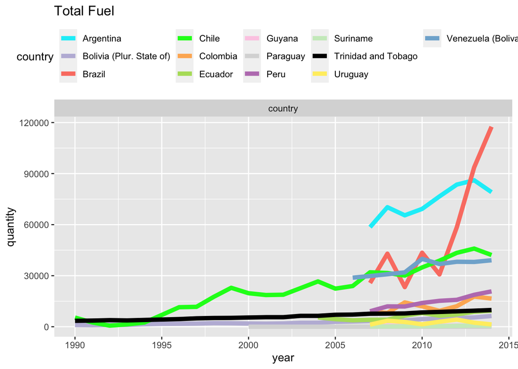

Figure 4: Producción de electricidad por combustibles fosiles

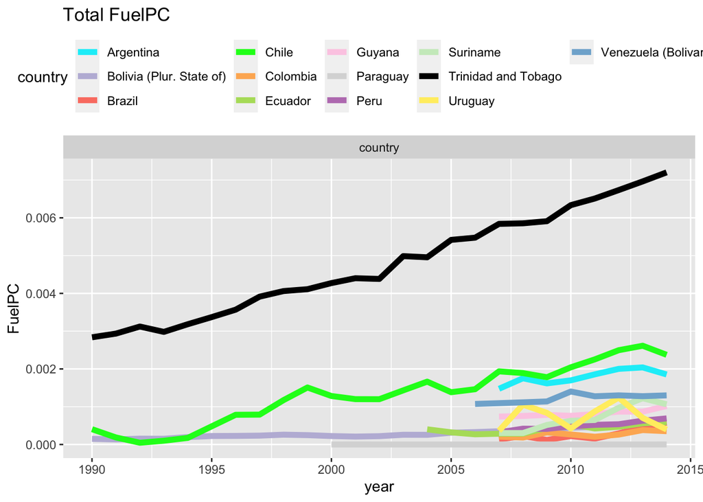

Figure 5: Producción de electricidad por combustibles fosiles per capita

**Producción total distintas fuentes**

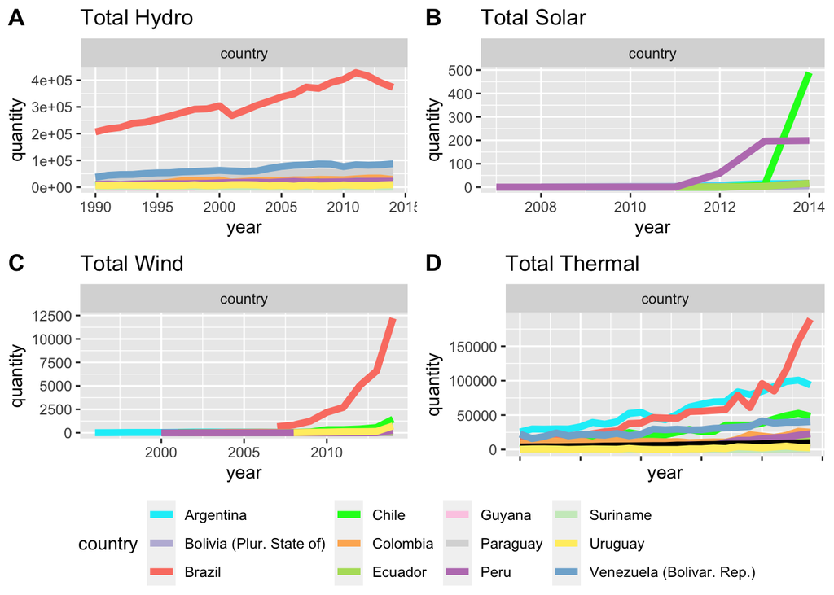

Figure 6: Producción de electricidad por distintas fuentes

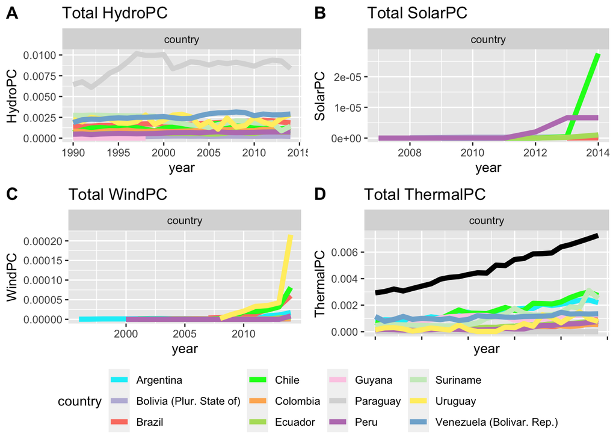

Figure 7: Producción de electricidad por distintas fuentes per capita

**Modelo**

Table 2: Proyecciones Modelo Actividad

| fit | lwr | upr |
| --- | --- | --- |
| 70697.94 | 69438.36 | 71957.52 |
| 73727.96 | 72354.73 | 75101.19 |
| 76998.17 | 75535.08 | 78461.26 |
| 80244.04 | 78663.12 | 81824.96 |
| 83099.10 | 81385.07 | 84813.13 |

Table 3: Proyecciones Modelo Producción Eolica

| fit | lwr | upr |
| --- | --- | --- |
| 1283.32 | 540.33 | 2026.31 |
| 1519.45 | 588.59 | 2450.31 |
| 1630.35 | 675.25 | 2585.46 |
| 1778.64 | 750.81 | 2806.47 |
| 2163.59 | 754.89 | 3572.30 |

Table 4: Proyecciones Modelo Producción por combustible

| fit | lwr | upr |
| --- | --- | --- |
| 44497.58 | 41730.06 | 47265.10 |
| 46638.71 | 43621.49 | 49655.94 |
| 49720.02 | 46505.36 | 52934.68 |
| 52573.89 | 49100.33 | 56047.44 |
| 53721.80 | 49955.77 | 57487.82 |

## 0.4 Discusión

- Los mayores productores de electricidad en la región son Brasil, Venezuela y Argentina.
- Algunas tecnologías como la producción solar o mediante viento aparecen como factor relevante bien avanzado los 2000 y solo en algunos países.
- En el caso de la producción de energía mediante radiación solar Chile presenta un liderazgo notable con un claro aumento desde 2013.

## 0.5 Conclusión

En términos de producción total de energía eléctrica Sudamérica tiene claros lideres, Brasil, Venezuela y Argentina. Pero con el cambio a la producción con energías renovables aparecen nuevos lideres como Chile en términos de generación Solar